# Model assessment

Published

26 Mar 2023

## loss functions (regression/quantitative outcome)

- continuous: L2, L1, **Huber loss**:

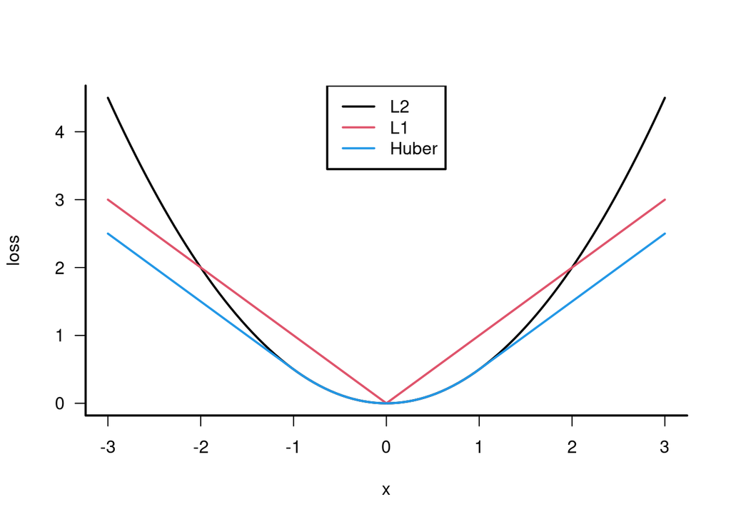

```r
par(las = 1, bty = "l", lwd = 2)
huber <- function(x, d) ifelse(abs(x)<d, x^2/2, d*abs(x)-d/2)
curve(x^2/2, from = -3, to = 3, ylab = "loss")
curve(abs(x), add = TRUE, col = 2)
curve(huber(x, 1), add = TRUE, col = 4)
legend("top", c("L2", "L1", "Huber"), col = c(1, 2, 4), lty = 1)
```

## loss functions (classification)

- 0-1
- **deviance**: $-2 \sum I(G=k) \log \hat p_k$ = -2 $\times$ log-likelihood
- deviance generalizes to other distributions

## a short rant about categorical loss functions

- 0-1 scoring dichotomizes prematurely
- leads to lots of confusing discussion about balancing data sets
- lots of discussion of what to do about imbalanced data sets (SMOTE etc.) (Chawla et al. 2002; van den Goorbergh et al. 2022)
- when **should** we balance?
  - when we have to use 0-1 scoring for some technical reason
  - when we have too **much** data (downsampling, i.e., throw away majority class)
- (cf. discussion of variable selection)

Chawla, N. V., K. W. Bowyer, L. O. Hall, and W. P. Kegelmeyer. 2002. “SMOTE: Synthetic Minority Over-Sampling Technique.” *Journal of Artificial Intelligence Research* 16 (June): 321–57. https://doi.org/10.1613/jair.953.

van den Goorbergh, Ruben, Maarten van Smeden, Dirk Timmerman, and Ben Van Calster. 2022. “The Harm of Class Imbalance Corrections for Risk Prediction Models: Illustration and Simulation Using Logistic Regression.” *Journal of the American Medical Informatics Association*, June, ocac093. https://doi.org/10.1093/jamia/ocac093.

## from loss functions to model quality metrics

- categorical predictors:
- accuracy (total fraction correct); same problems as 0-1 classification
- AUC (area under the curve)
  - may be problematic in terms of implied misclassification costs? (Hand 2009)

Hand, David J. 2009. “Measuring Classifier Performance: A Coherent Alternative to the Area Under the ROC Curve.” *Machine Learning* 77 (1): 103–23. https://doi.org/10.1007/s10994-009-5119-5.

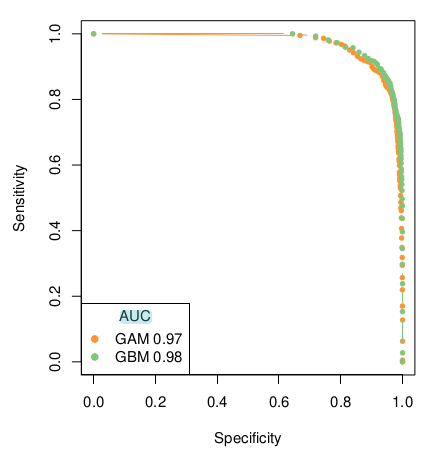

## quality metrics

- some combination of loss functions per point
- scaled for **interpretability**
  - how good is good enough?
  - how much difference in model predictions matters?
  - e.g. [Netflix prize](https://en.wikipedia.org/wiki/Netflix_Prize)
- $R^2$
- MSE $\to$ RMSE $\to$ scaled RMSE (or mean-squared log error?)
- always a **business** or **scientific** decision (*value of information*)

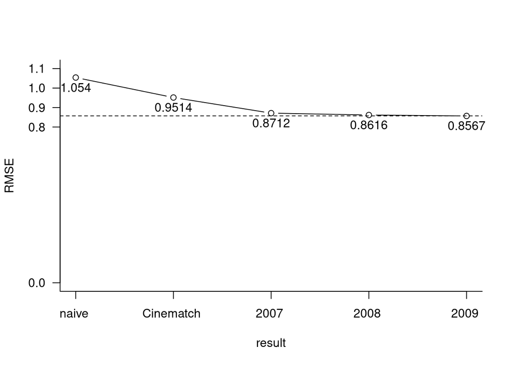

## what error are we trying to estimate?

- training error (within-sample): average error within sample
- test error (generalization error), ${\ensuremath{\textrm{Err}_{\cal T}}}$: expected prediction error for a **fixed** training sample
- **expected** prediction error: test error *averaged over training sets* = $E[{\ensuremath{\textrm{Err}_{\cal T}}}]$

## bias/variance etc.

$$E[f(x_0) - x_0^\top \beta^*]^2 + E[x_0^\top \beta^* - E x_0^\top \hat \beta_\alpha]^2$$

- estimation bias = 0 for linear regression etc., positive for ridge etc. **given correct model**

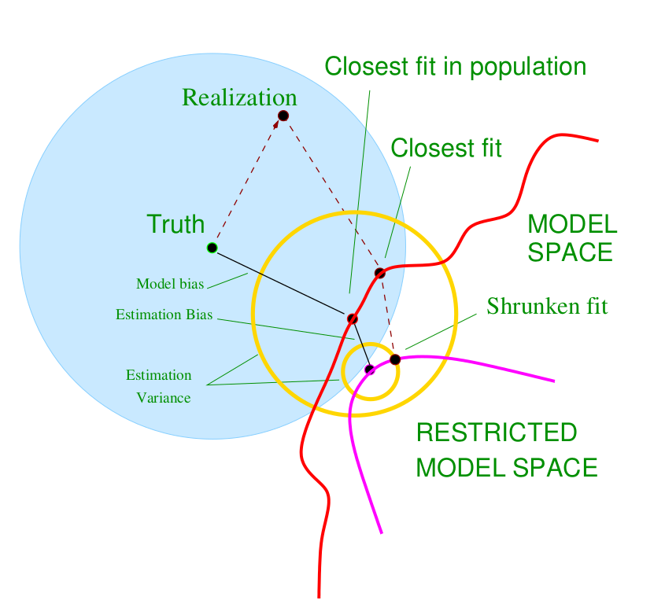

## train/validate/test

- training to estimate parameters
- validation: select models/tune hyperparameters
- test: evaluate; **must be independent**, don’t snoop!
- select models based on **estimated test error**: only need to get relative values right

## within- (training) and out-of-sample (test) error

- within-sample: $R^2$
- out-of-sample: adjusted $R^2$ (scaled by $n-p$), PRESS (predicted out-of-sample error) = LOOCV SSQ, AIC ($-2 \log L + 2 p$), Mallows’ $C_p$ ($\frac{\textrm{RSS} + 2 p \hat \sigma^2}{n}$). AIC and $C_p$ equivalent for Gaussian models. AIC asymptotically $\to$ LOOCV for linear models.
- finite-size corrections for AIC (AICc): more conservative for smaller samples
- ESL gives a weird/unusual (scaled-by-$N$) definition of AIC
- GCV, AUC
- BIC: $-2 \log L + (\log N) p$; higher penalty for $N > e^2$ (almost always)
  - derived from a **Laplace approximation** to the **Bayes factor** (quadratic approx; $\approx$ multivariate normal posterior) given equal priors on models
  - (¿ what is $N$ for non-iid data ?)
- BIC is **consistent**, AIC is **predictive** (Yang 2005); M-closed vs M-complete vs M-open (Clarke, Clarke, and Yu 2014)

Yang, Yuhong. 2005. “Can the Strengths of AIC and BIC Be Shared? A Conflict Between Model Identification and Regression Estimation.” *Biometrika* 92 (4): 937–50. https://doi.org/10.1093/biomet/92.4.937.

Clarke, Bertrand, Jennifer Clarke, and Chi Wai Yu. 2014. “Statistical Problem Classes and Their Links to Information Theory.” *Econometric Reviews* 33 (1-4): 337–71. https://doi.org/10.1080/07474938.2013.807190.

## effective number of parameters

- (generalized, penalized) linear models: trace(Hat)
- additive-error models: $\sum(\textrm{Cov}(\hat y_i, y)/\sigma^2_\epsilon)$

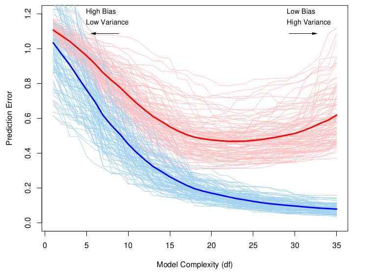

## cross-validation

- typical used for **hyperparameter tuning** (e.g. ridge/lasso/spline penalty, elasticnet $\alpha$)
- LOOCV
  - sometimes easy/closed-form solution
  - expensive otherwise
- $k$-fold

## bias vs variance in CV

- more folds = smaller folds = larger training sets
- training error decreases with training set size (i.e. **decreasing** bias in error estimate)
- high variance because training sets are highly correlated (i.e., we’re estimating ${\ensuremath{\textrm{Err}_{\cal T}}}$)

## one-standard-error rule

- account for uncertainty in cross-validation error estimate; choose a slightly more **parsimonious** (i.e. higher penalty/lower complexity) model than min-CV
- ¿ not on strong foundations ? “Occam’s razor”: is there a general trend toward overoptimism?
- [CrossValidated q.](https://stats.stackexchange.com/questions/80268/empirical-justification-for-the-one-standard-error-rule-when-using-cross-validat)
- Chen and Yang (2021)

Chen, Yuchen, and Yuhong Yang. 2021. “The One Standard Error Rule for Model Selection: Does It Work?” *Stats* 4 (4): 868–92. https://doi.org/10.3390/stats4040051.

## data leakage

- inadmissible predictors (e.g. palliative care in Cygu et al. (2023))
- ESL $\S$ 7.10.2
  - example: screen predictors first
  - then use CV to tune the model
  - the **full** ‘training’ sequence must be done on every CV training set
    - can do **unsupervised** model reduction (i.e., not looking at predictions), e.g. select PCA components or high-variance predictors

Cygu, Steve, Hsien Seow, Jonathan Dushoff, and Benjamin M. Bolker. 2023. “Comparing Machine Learning Approaches to Incorporate Time-Varying Covariates in Predicting Cancer Survival Time.” *Scientific Reports* 13 (1): 1370. https://doi.org/10.1038/s41598-023-28393-7.

## dependent data

- blocking factors: patient, space, time, etc. (Wenger and Olden 2012; Bussola et al. 2020)

Wenger, Seth J., and Julian D. Olden. 2012. “Assessing Transferability of Ecological Models: An Underappreciated Aspect of Statistical Validation.” *Methods in Ecology and Evolution* 3 (2): 260–67. https://doi.org/10.1111/j.2041-210X.2011.00170.x.

Bussola, Nicole, Alessia Marcolini, Valerio Maggio, Giuseppe Jurman, and Cesare Furlanello. 2020. “AI Slipping on Tiles: Data Leakage in Digital Pathology.” arXiv. https://doi.org/10.48550/arXiv.1909.06539.

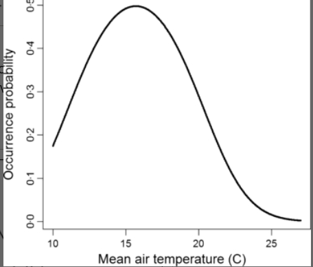

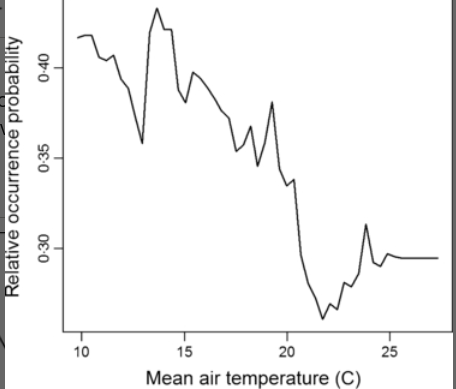

## solutions

- consider admissibility of predictors
- stratify CV folds
- organize spatially blocked or buffered test/train splits (Roberts et al. 2017; Valavi et al. 2019; Milà et al. 2022)
- account for blocking/correlation in the model (mixed models, spatial correlation models …?)

Roberts, David R., Volker Bahn, Simone Ciuti, Mark S. Boyce, Jane Elith, Gurutzeta Guillera-Arroita, Severin Hauenstein, et al. 2017. “Cross-Validation Strategies for Data with Temporal, Spatial, Hierarchical, or Phylogenetic Structure.” *Ecography* 40 (8): 913–29. https://doi.org/10.1111/ecog.02881.

Valavi, Roozbeh, Jane Elith, José J. Lahoz-Monfort, and Gurutzeta Guillera-Arroita. 2019. “blockCV: An r Package for Generating Spatially or Environmentally Separated Folds for k-Fold Cross-Validation of Species Distribution Models.” *Methods in Ecology and Evolution* 10 (2): 225–32. https://doi.org/10.1111/2041-210X.13107.

Milà, Carles, Jorge Mateu, Edzer Pebesma, and Hanna Meyer. 2022. “Nearest Neighbour Distance Matching Leave-One-Out Cross-Validation for Map Validation.” *Methods in Ecology and Evolution* 13 (6): 1304–16. https://doi.org/10.1111/2041-210X.13851.

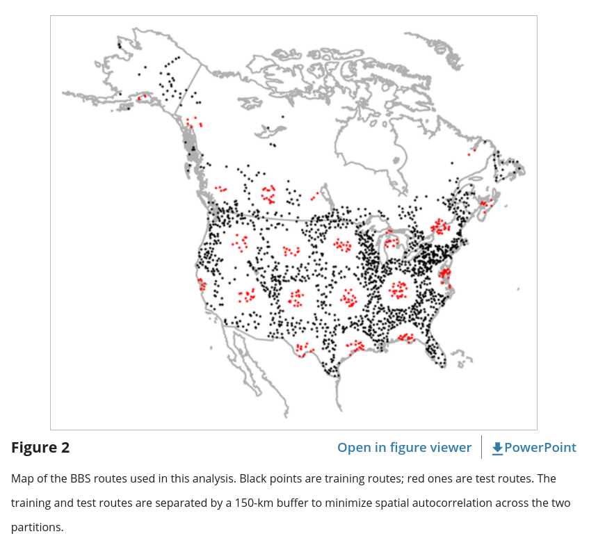

## bootstrapping

- we can also use bootstrapping
- $\widehat{\textrm{Err}}_{\textrm{\small boot}}= \frac{1}{B} \frac{1}{N} \sum_b \sum_i L(y_i, {\hat f}^{*b}(x_i))$  
  (applies bootstrap estimate to *training data*: overlap of $\phi_b = \approx 1-e^{-1}$
- **leave-one-out bootstrap error**: $\widehat{\textrm{Err}}_{\textrm{\small boot}}^{(1)}$: only average $L(i)$ over bootstrap replicates not containing $i$
- bias correction for smallness of bootstrap set: $(1-\phi_b) \cdot \textrm{sample error} + \phi_b \cdot \widehat{\textrm{Err}}_{\textrm{\small boot}}^{(1)}$

## nested cross-validation

Kuhn (2017)

Kuhn, Max. 2017. “Nested Resampling with Rsample.” *Applied Predictive Modeling*. http://appliedpredictivemodeling.com/blog/2017/9/2/njdc83d01pzysvvlgik02t5qnaljnd.

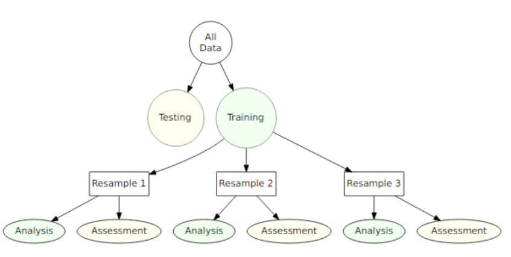

> Nested resampling does an additional layer of resampling that separates the tuning activities from the process used to estimate the efficacy of the model. … For example, if 10-fold cross-validation is used on the outside and 5-fold cross-validation on the inside, a total of 500 models will be fit. The parameter tuning will be conducted 10 times and the best parameters are determined from the average of the 5 assessment sets.

> Once the tuning results are complete, a model is fit to each of the outer resampling splits using the best parameter associated with that resample. The average of the outer method’s assessment sets are a unbiased estimate of the model.
- maybe overkill for practical purposes (Wainer and Cawley 2021) ?

Wainer, Jacques, and Gavin Cawley. 2021. “Nested Cross-Validation When Selecting Classifiers Is Overzealous for Most Practical Applications.” *Expert Systems with Applications* 182 (November): 115222. https://doi.org/10.1016/j.eswa.2021.115222.

## from model assessment to uncertainty estimation

- RMSE is the *average* inaccuracy; use it as a standard error?
- conformal prediction (Shafer and Vovk 2008)
- jackknife (Barber et al. 2021; Efron and Gong 1983)
  - $R_i^{\textrm{\small LOO}}$ is the leave-one-out residual for point $i$
  - jackknife pred interval: quantiles of $\hat \mu(X_{n+1}) \pm R_i^{\textrm{\small LOO}}$
  - jackknife+: quantiles of $\hat\mu_{-i}(X_{n+1}) \pm R_i^{\textrm{\small LOO}}$
  - **or** $K$-fold CV+ intervals (Taquet 2021)

Shafer, Glenn, and Vladimir Vovk. 2008. “A Tutorial on Conformal Prediction.” *Journal of Machine Learning Research* 9: 371–421.

Barber, Rina Foygel, Emmanuel J. Candès, Aaditya Ramdas, and Ryan J. Tibshirani. 2021. “Predictive Inference with the Jackknife+.” *The Annals of Statistics* 49 (1): 486–507. https://doi.org/10.1214/20-AOS1965.

Efron, Bradley, and Gail Gong. 1983. “A Leisurely Look at the Bootstrap, the Jackknife, and Cross-Validation.” *The American Statistician* 37 (1): 36–48. https://doi.org/10.1080/00031305.1983.10483087.

Taquet, Vianney. 2021. “With MAPIE, Uncertainties Are Back in Machine Learning !” *Medium*. https://towardsdatascience.com/with-mapie-uncertainties-are-back-in-machine-learning-882d5c17fdc3.

## coverage

- a measure of the accuracy of confidence intervals
- do $(1-\alpha)$ CIs include the true value a fraction $\alpha$ of the time?
- $\approx$ accuracy of model assessment
- [MAPIE](https://mapie.readthedocs.io/en/latest/quick_start.html)

## calibration

- for categorical prediction
- do predicted probabilities match observed probabilities (e.g. fraction of positives)?
- (Guo et al. 2017; Minderer et al. 2021)

Guo, Chuan, Geoff Pleiss, Yu Sun, and Kilian Q. Weinberger. 2017. “On Calibration of Modern Neural Networks.” In *Proceedings of the 34th International Conference on Machine Learning*, 1321–30. PMLR. https://proceedings.mlr.press/v70/guo17a.html.

Minderer, Matthias, Josip Djolonga, Rob Romijnders, Frances Hubis, Xiaohua Zhai, Neil Houlsby, Dustin Tran, and Mario Lucic. 2021. “Revisiting the Calibration of Modern Neural Networks.” In *Advances in Neural Information Processing Systems*, 34:15682–94. Curran Associates, Inc. https://proceedings.neurips.cc/paper/2021/hash/8420d359404024567b5aefda1231af24-Abstract.html.

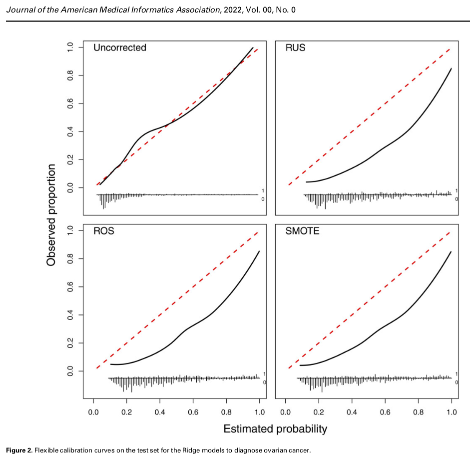

# Model/parameter interpretation

## goals

- wanting **pure** prediction is very unusual
- evaluate effects of variables on predictions
- tell a story/interpret results
- prioritize data collections
- counterfactuals (**not** causal inference!)
  - **danger**: strong assumptions of representative sampling etc.
  - effects of correlated predictors
- *conditional* vs *marginal* effects
  - “marginal” as in “marginal probability”
    - any nonlinearity makes $E(f(\beta)) \neq f(E(\beta))$
  - “marginal” as in “marginal effect” (**partial derivative** of predictions wrt predictors) [“average” marginal effects]

## by variable: p-values

- de-emphasized/impractical
- usually parameter-specific
- usually model-dependent (although permutation test)
- theory difficult under penalization,
- measure clarity, not effect size
- usually messed up by penalization, hyperparameter tuning, etc..
- multiple-comparisons testing
  - **false discovery rate** (Benjamini-Hochberg)
    - rank $p$-values
    - critical value $(i/m)Q$
    - all $p$-values $<$ crit value are significant
- **high-dimensional inference**: e.g.
  - asymptotic assumptions
  - requires sparsity (e.g. $\log(p)/\sqrt{n} \to 0$
  - may require a bound on the smallest non-zero parameter

## by variable: “relevance”

- “relevance”
- single CART: average improvement (decrease of squared loss) over splits that use variable $v$
- boosted trees: average over trees
- (splits importance between strongly correlated predictors …)
- do we have to worry about overfitting (training vs testing)?

## permutation measures

- random forests: permute $j$th variable in OOB samples, compare accuracy
- can be generalized, but expensive
- more even: correlated variables can be substituted

## partial dependence

- $S$ = focal variable, $C$ = complement (all other variables)
- average dependence: $f_S(X_S) = E_{X_C} f(X_S, X_C)$
- $\to \bar f_S(X_S) = \frac{1}{N} \sum f(X_S, x_{iC})$
- compare with **individual conditional** expectations
  - plot predictions for observations $i$ while modifying $X_S$
  - could plot effects at **model centre** (‘average individual’)

## Shapley values

- Game theoretic
- *average additive* contributions/decreases in loss rate
- … over all possible combinations of previously included variables
- fast algorithm for trees
- challenges … Kumar et al. (2020)

Kumar, I. Elizabeth, Suresh Venkatasubramanian, Carlos Scheidegger, and Sorelle Friedler. 2020. “Problems with Shapley-value-based Explanations as Feature Importance Measures.” In *Proceedings of the 37th International Conference on Machine Learning*, 5491–5500. PMLR. http://proceedings.mlr.press/v119/kumar20e/kumar20e.pdf.

Burzykowski, Przemyslaw Biecek and Tomasz. 2020. *Explanatory Model Analysis*.

See Burzykowski (2020) for more details …